# Illustration of SuSie model for fine-mapping

Peter Carbonetto

November 28, 2017

This is a small example to compare the fully-factorized variational approximation against the SuSiE (“Sum of Single Effects”) approach for fine-mapping. Here, the phenotype is expression of the *FMO2* gene. The data are genotypes from the GTEx study, and simulated phenotypes.

## Script parameters

```r
k     <- 3       # Number of nonzero effects in model
sigma <- 9       # Variance of residual.
sa    <- 2       # Prior variance of nonzero effects.
pp    <- 3/1000  # Prior inclusion probability.
```

These are the additive effects used to simulate the phenotype data.

```r
beta                 <- rep(0,1000)
beta[c(201,562,952)] <- c(3,-3,5)
```

## Set up environment

Load some functions and packages used in this example.

```r
library(varbvs)
library(ggplot2)
library(cowplot)
source("varbvssusie.R")
```

Set the sequence of pseudorandom numbers (useful for making sure that the results are reproducible).

```r
set.seed(1)
```

## Load genotype data

Retrieve genotype data for 1,000 SNPs near gene *FMO2*.

```r
load("../datafiles/Thyroid.FMO2.1Mb.RData")
rm(Z,y)
X <- X[,3501:4500]
n <- nrow(X)
p <- ncol(X)
storage.mode(X) <- "double"
```

Center the columns of the genotype matrix.

```r
X <- scale(X,center = TRUE,scale = FALSE)
```

## Simulate phenotype data

I also center the phenotypes.

```r
y <- c(X %*% beta + sqrt(sigma)*rnorm(n))
y <- y - mean(y)
```

## Fit fully-factorized variational approximation

Note that changing the update order will result in very different results.

```r
alpha0  <- runif(p)
alpha0  <- alpha0/sum(alpha0)
mu0     <- rnorm(p)
pp      <- rep(pp,1,p)
logodds <- varbvs:::logit(pp)
fit1    <- varbvsnorm(X,y,sigma,sa,logodds,alpha0,mu0,update.order = 1:p,
                      update.sigma = FALSE,update.sa = FALSE,tol = 1e-6,
                      verbose = FALSE)
```

## Fit “SuSiE” variational approximation

We see that the co-ordinate ascent updates converge to a stationary point more rapidly than the updates for the fully-factorized approximation.

```r
fit2 <- varbvssusie(X,y,k,sigma,sa,pp,tol = 1e-6,maxiter = 100)
#              variational    max.
# iter         lower bound  change
# 0001 -1.466913662292e+03 8.9e-02
# 0002 -1.463295735669e+03 2.6e-01
# 0003 -1.462673341439e+03 1.7e-01
# 0004 -1.462575669232e+03 5.1e-02
# 0005 -1.462563617173e+03 2.2e-02
# 0006 -1.462562319844e+03 4.4e-03
# 0007 -1.462562178954e+03 1.8e-03
# 0008 -1.462562163455e+03 5.6e-04
# 0009 -1.462562161717e+03 1.6e-04
# 0010 -1.462562161520e+03 6.9e-05
# 0011 -1.462562161497e+03 1.5e-05
# 0012 -1.462562161494e+03 8.3e-06
# 0013 -1.462562161494e+03 1.5e-06
# 0014 -1.462562161494e+03 9.8e-07
```

## Summarize results

Not sure it is appropriate to do so, but I thought it might be interesting to compare the “fit” of the two models by comparing the variational lower bounds to the marginal likelihoods.

```r
cat("Approximate marginal log-likelihoods:\n")
last <- function (x) x[length(x)]
cat(sprintf("varbvsnorm  = %0.6f\n",last(fit1$logw)))
cat(sprintf("varbvssusie = %0.6f\n",last(fit2$logw)))
cat(sprintf("Improvement in likelihood using SuSie model: %0.2e\n",
            exp(last(fit2$logw) - last(fit1$logw))))
# Approximate marginal log-likelihoods:
# varbvsnorm  = -1484.801065
# varbvssusie = -1462.562161
# Improvement in likelihood using SuSie model: 4.55e+09
```

Show convergence of the co-ordinate ascent updates for the two methods.

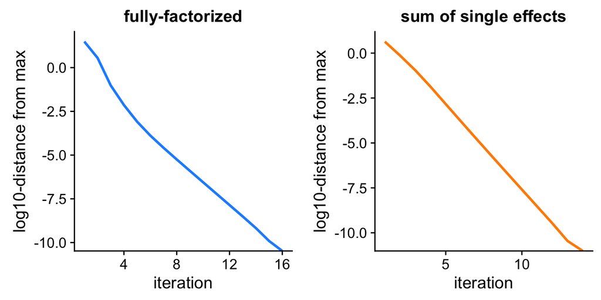

```r
plot.progress <- function (logw, clr, plot.title)
  ggplot(data.frame(x = 1:length(logw),
                    y = log10(max(logw) - logw)),
         aes(x = x,y = y)) +
  geom_line(color = clr,size = 1) +
  labs(x = "iteration",y = "log10-distance from max",title = plot.title)
p1 <- plot.progress(fit1$logw,"dodgerblue","fully-factorized")
p2 <- plot.progress(fit2$logw,"darkorange","sum of single effects")
plot_grid(p1,p2)
```

We observe that both algorithms progress rapidly to a fixed point, at least in this example.

Next, I plot the posterior inclusion probabilities (PIPs) under the fully-factorized variational approximation, and under the SuSiE model. For the SuSiE model, I show, for each SNP, the posterior probability that one or more of the coefficients is nonzero, which is easily calculated under the variational approximation.

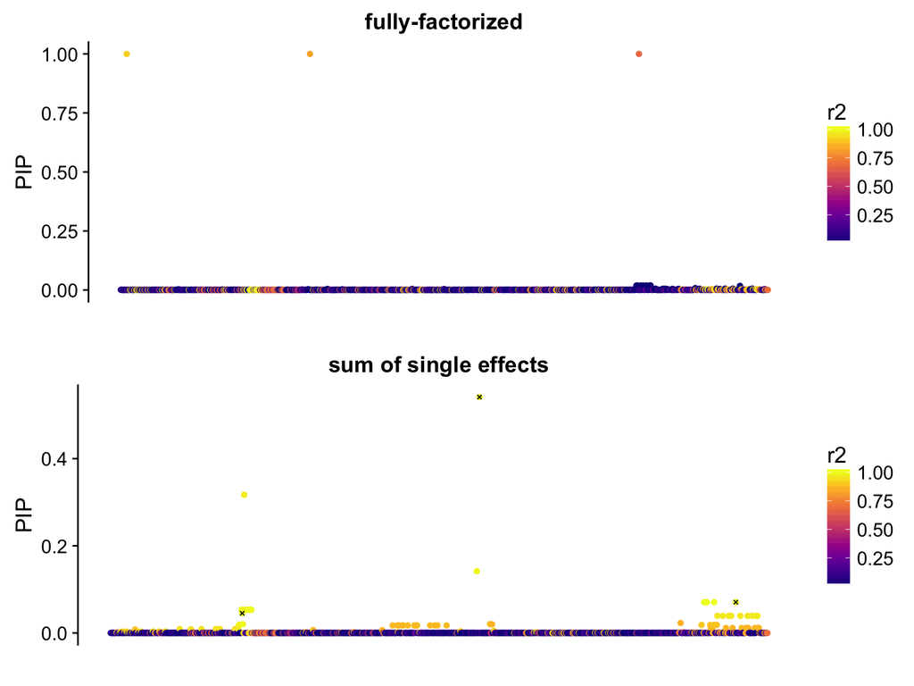

```r
plot.pips <- function (pip, r2, plot.title) {
  n    <- length(pip)
  clrs <- c("#0D0887FF","#5402A3FF","#8B0AA5FF","#B93289FF",
            "#DB5C68FF","#F48849FF","#FEBC2AFF","#F0F921FF")
  return(ggplot(data.frame(x = 1:p,y = pip,r2 = r2),
             aes(x = x,y = y,color = r2)) +
    geom_point(shape = 20,size = 2) +
    scale_x_continuous(breaks = NULL) +
    scale_color_gradientn(colors = clrs) +
    labs(x = "",y = "PIP",title = plot.title))
}
markers <- which(beta != 0)
r2  <- apply((cor(X)^2)[,markers],1,max)
pip <- 1 - apply(1 - fit2$alpha,1,prod)
p3  <- plot.pips(fit1$alpha,r2,"fully-factorized")
p4  <- plot.pips(pip,r2,"sum of single effects") +
         geom_point(data = data.frame(x = markers,y = pip[markers]),
                    aes(x = x,y = y),color = "black",shape = 4,
                    size = 0.75)
print(plot_grid(p3,p4,nrow = 2))
```

Additionally, to understand how the the SuSiE model captures uncertainty in the location of the SNP effect, I used colour to show correlation strength (LD) with the true effects. In the lower panel, the SNPs with (true) effects on the phenotype are marked with x’s.

## Session information

Here are details about the computing environment that I used to generate these results, including the version of R that was used, and the versions of the packages that were loaded into the R session.

```r
sessionInfo()
# R version 3.4.1 (2017-06-30)
# Platform: x86_64-apple-darwin15.6.0 (64-bit)
# Running under: macOS Sierra 10.12.6
#
# Matrix products: default
# BLAS: /Library/Frameworks/R.framework/Versions/3.4/Resources/lib/libRblas.0.dylib
# LAPACK: /Library/Frameworks/R.framework/Versions/3.4/Resources/lib/libRlapack.dylib
#
# locale:
# [1] en_US.UTF-8/en_US.UTF-8/en_US.UTF-8/C/en_US.UTF-8/en_US.UTF-8
#
# attached base packages:
# [1] stats     graphics  grDevices utils     datasets  methods   base
#
# other attached packages:
# [1] rmarkdown_1.7 cowplot_0.8.0 ggplot2_2.2.1 varbvs_2.4-16
#
# loaded via a namespace (and not attached):
#  [1] Rcpp_0.12.13        knitr_1.17          magrittr_1.5
#  [4] munsell_0.4.3       colorspace_1.3-2    lattice_0.20-35
#  [7] rlang_0.1.2         nor1mix_1.2-3       stringr_1.2.0
# [10] plyr_1.8.4          tools_3.4.1         grid_3.4.1
# [13] gtable_0.2.0        latticeExtra_0.6-28 htmltools_0.3.6
# [16] yaml_2.1.14         lazyeval_0.2.1      digest_0.6.12
# [19] rprojroot_1.2       tibble_1.3.4        Matrix_1.2-10
# [22] RColorBrewer_1.1-2  evaluate_0.10.1     labeling_0.3
# [25] stringi_1.1.5       compiler_3.4.1      scales_0.4.1.9002
# [28] backports_1.1.0
```